# Genomics_Project

# 1 Introduction

Data from patients with a variant of cardiomyopathy will be studied in order get familiar with the process of analyzing sequenced DNA. The goal of this project is to spot genomic variations which may correlate to the disease.

## 1.1 Cardiomyopathy

*Cardiomyopathy is a disease which affects the heart muscle.*

## 1.2 Tools

| Tool | Purpose |
| --- | --- |
| RStudio | Writing documentation |
| Galaxy | Data processing pipeline |

# 2 Data

The raw data is a `fastQ.gz` file, which includes DNA strands resulted from sequencing as well as some information about the sequencing process. This is the first entry of the file:

```
@M01234:01:000000000-A1B2C:1:1101:16810:1655 2:N:0:2
AATGACATTGATCTCCACAGCCATCAAGAGCCCATTCAAGATGACCATCATGCCTGTGATGCAGAAACGCAGGTTTGATATGTCCAAGCCAGACTGACAGTACTTAACCAATTTTATTGTTTTTGTAATAAAGGCCCTTACCCAATACAGG
+
11A11DDFDDB@GGGGCF11FA1GGF1GBCCBFHHHHGHFCGHFFHFHB1F1FFHBF1BG2DFBGF1FC/EE/A1D/1A2DBGGHFFFE/000FG11BF1GFGFHHFHHEHHHGHHGBDFHFHG/BE2F2>FH1>E/FE11BG</B1<110
```

Each line describes the following:

- An identifier for the sequencing machine, the chip it used and the specific position within it.
- The DNA nucleotides in order given by the sequence.
- A plus sign.
- A corresponding quality identifier for each nucleotide, also given by the sequencer.

## 2.1 Quality Control

To evaluate the quality of the sequenced data the tool `Falco` was used. In this case we will input a `.fastQ.gz` file and receive several plots as output. Each plot points out a specific aspect of the data regarding quality and provides a score in the form of pass, warn or fail.

```
Falco An alternative, more performant implementation of FastQC for high throughput sequence quality control
(Galaxy Version 1.2.4+galaxy0)
```

Tool parameters set to *default*.

### 2.1.1 Basic Statistics

| Measure | Value |
| --- | --- |
| Filename |  |
| File type | Conventional base calls |
| Encoding | Sanger / Illumina 1.9 |
| Total Sequences | 1424257 |
| Sequences Flagged As Poor Quality | 0 |
| Sequence length | 32 - 151 |
| %GC: | 43 |

### 2.1.2 [Per base sequence quality](https://www.bioinformatics.babraham.ac.uk/projects/fastqc/Help/3%20Analysis%20Modules/2%20Per%20Base%20Sequence%20Quality.html)

This graph shows the quality values average in each base pair position read. The middle line is the median value, the boxes represent the inner 25% to 75% and the whiskers are the 10% and 90% points.

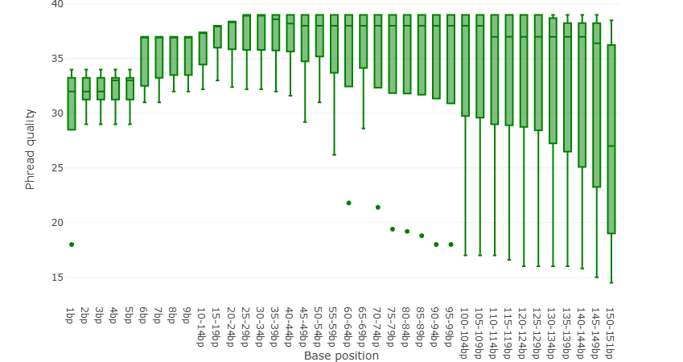

This test resulted in a pass. This is because no value is below 10 and no median is below 25. Quality decreases at the end of the sequences due to [phasing](https://www.ecseq.com/support/ngs/why-does-the-sequence-quality-decrease-over-the-read-in-illumina). This is a small chance that a nucleotide is misplaced, which with longer sequences adds up.

### 2.1.3 [Per tile sequence quality](https://www.bioinformatics.babraham.ac.uk/projects/fastqc/Help/3%20Analysis%20Modules/12%20Per%20Tile%20Sequence%20Quality.html)

This test gives quality scores on each base pair position per tile in the sequencer flow cell. A heat map like pattern represents above average values with cold colors and below average values with hot ones.

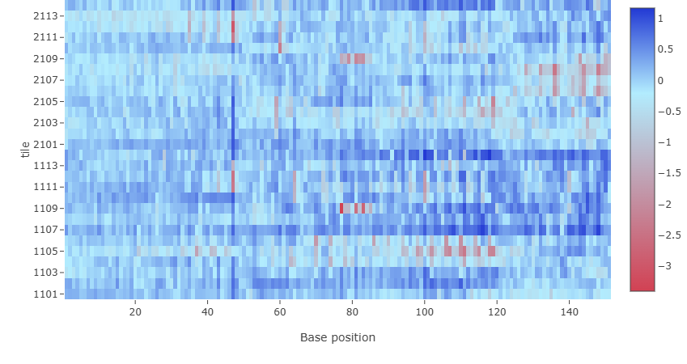

The test resulted in a pass and there are no consistent low values for any given tile.

### 2.1.4 [Per sequence quality scores](https://www.bioinformatics.babraham.ac.uk/projects/fastqc/Help/3%20Analysis%20Modules/3%20Per%20Sequence%20Quality%20Scores.html)

This plot shows the amount of sequences per Phred score, the highest density value being the average score.

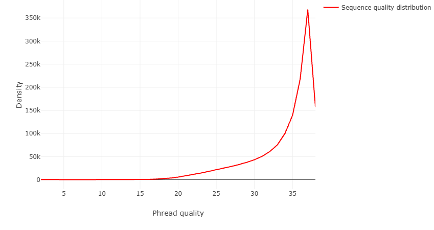

This test resulted in a pass as the most frequently observed values are above 27.

### 2.1.5 [Per base sequence content](https://www.bioinformatics.babraham.ac.uk/projects/fastqc/Help/3%20Analysis%20Modules/4%20Per%20Base%20Sequence%20Content.html)

Here the percentage amount of each nucleotide A, C, T and G is plotted per base pair position. It is expected to have a equally consistent amount of A and T as well as C and G.

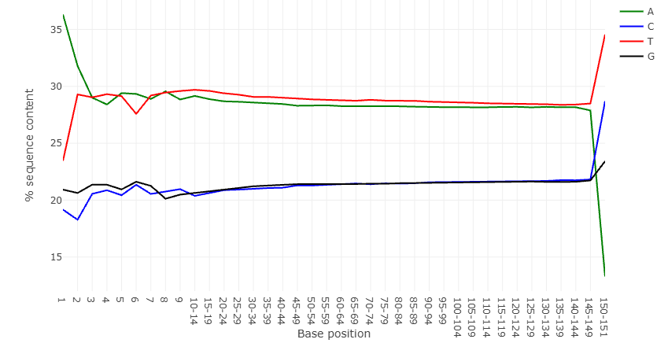

This test resulted in a fail. However, all sequencers produce inaccurate readings for this test at the start of the sequence.

### 2.1.6 [Per sequence GC content](https://www.bioinformatics.babraham.ac.uk/projects/fastqc/Help/3%20Analysis%20Modules/5%20Per%20Sequence%20GC%20Content.html)

This plot shows the Guanine and Cytosine percent amount against a theoretical normal distribution.

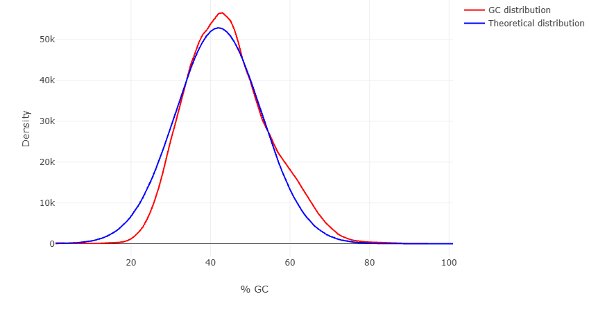

The result is a pass given that the sum of deviation from the normal distribution does not exceed 15% of all reads.

### 2.1.7 [Per base N content](https://www.bioinformatics.babraham.ac.uk/projects/fastqc/Help/3%20Analysis%20Modules/6%20Per%20Base%20N%20Content.html)

If the sequencer is unable to confidently assign a base it will substitute it with an N. This test shows the percent amount of N per base pair position.

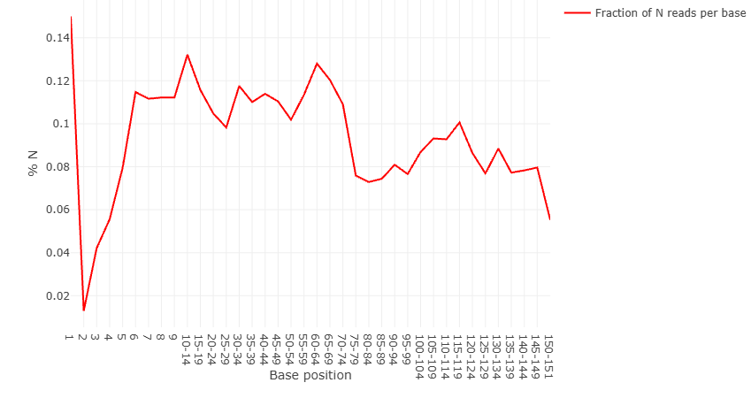

The test resulted in a pass, because no position has more than 5%.

### 2.1.8 [Sequence Length Distribution](https://www.bioinformatics.babraham.ac.uk/projects/fastqc/Help/3%20Analysis%20Modules/7%20Sequence%20Length%20Distribution.html)

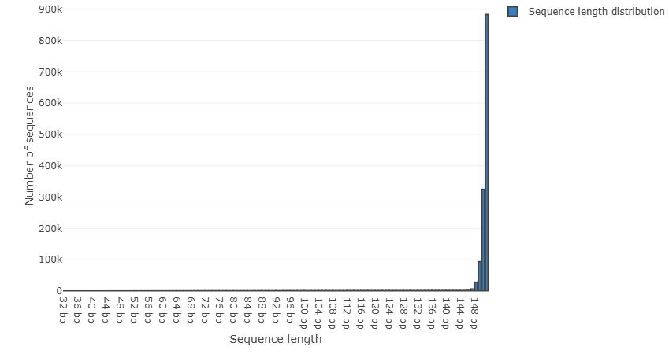

### 2.1.9 [Sequence Duplication Levels](https://www.bioinformatics.babraham.ac.uk/projects/fastqc/Help/3%20Analysis%20Modules/8%20Duplicate%20Sequences.html)

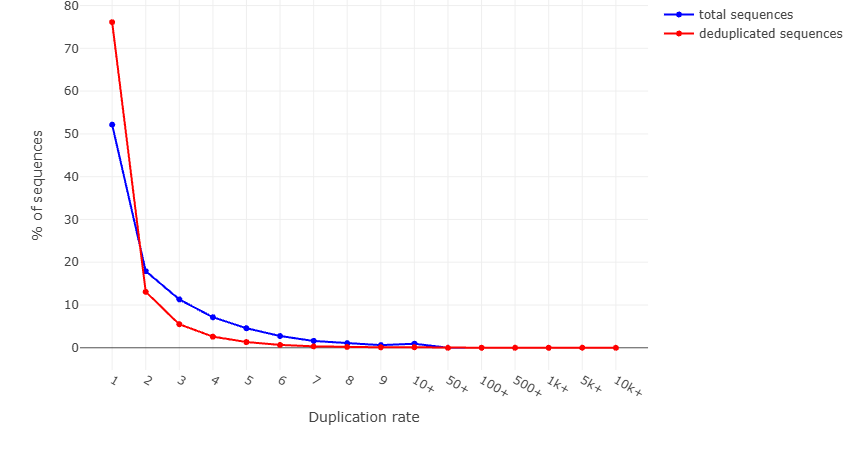

## 2.2 Trimming

The next step is to trim the data and keep only values with a certain minimum quality score. For this the tool `Trimmomatic` was used.

```
Trimmomatic flexible read trimming tool for Illumina NGS data
(Galaxy Version 0.39+galaxy2)
```

`Trimmomatic` outputs 2 sets of files, 2 paired and 2 unpaired for the corresponding R1 and R2 strands. Some discarded sequences from one strand may have not been discarded on the other, these are shown on the unpaired files. The paired files show only matching non-discarded sequences in both strands. We will only continue with the paired files.

In order to compare the trimmed values the `Falco` tool was used, but this time on the trimmed data. Multiple iteration of the trim with different tool inputs were done.

### 2.2.1 First trim

| Input Parameter | Value |
| --- | --- |
| Single-end or paired-end reads? | pair_of_files |
| Input FASTQ file (R1/first of pair) | *R1 file* |
| Input FASTQ file (R2/second of pair) | *R2 file* |
| Perform initial ILLUMINACLIP step? | true |
| Select standard adapter sequences or provide custom? | standard |
| Adapter sequences to use | TruSeq3 (paired-ended, for MiSeq and HiSeq) |
| Maximum mismatch count which will still allow a full match to be performed | 2 |
| How accurate the match between the two ‘adapter ligated’ reads must be for PE palindrome read alignment | 30 |
| How accurate the match between any adapter etc. sequence must be against a read | 10 |
| Minimum length of adapter that needs to be detected (PE specific/palindrome mode) | 8 |
| Always keep both reads (PE specific/palindrome mode)? | true |
| Select Trimmomatic operation to perform | SLIDINGWINDOW |
| Number of bases to average across | 4 |
| Average quality required | 20 |
| Select Trimmomatic operation to perform | MINLEN |
| Minimum length of reads to be kept | 70 |
| Quality score encoding | Nothing selected. |
| Output trimlog file? | false |
| Output trimmomatic log messages? | false |

#### 2.2.1.1 Basic Statistics

| Measure | Value |
| --- | --- |
| Filename |  |
| File type | Conventional base calls |
| Encoding | Sanger / Illumina 1.9 |
| Total Sequences | 1172109 |
| Sequences Flagged As Poor Quality | 0 |
| Sequence length | 70 - 151 |
| %GC: | 42 |

#### 2.2.1.2 Per base sequence quality

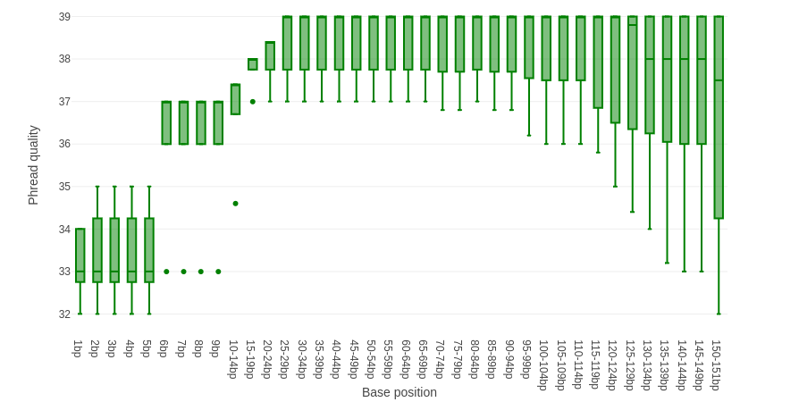

Forward trand

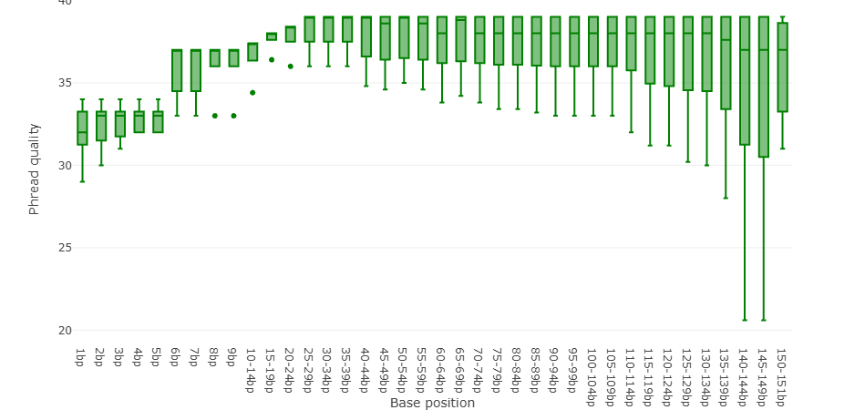

Reverse strand

### 2.2.2 Second trim

| Input Parameter | Value |
| --- | --- |
| Single-end or paired-end reads? | pair_of_files |
| Input FASTQ file (R1/first of pair) | *R1 file* |
| Input FASTQ file (R2/second of pair) | *R2 file* |
| Perform initial ILLUMINACLIP step? | true |
| Select standard adapter sequences or provide custom? | standard |
| Adapter sequences to use | TruSeq3 (paired-ended, for MiSeq and HiSeq) |
| Maximum mismatch count which will still allow a full match to be performed | 2 |
| How accurate the match between the two ‘adapter ligated’ reads must be for PE palindrome read alignment | 30 |
| How accurate the match between any adapter etc. sequence must be against a read | 10 |
| Minimum length of adapter that needs to be detected (PE specific/palindrome mode) | 8 |
| Always keep both reads (PE specific/palindrome mode)? | true |
| Select Trimmomatic operation to perform | SLIDINGWINDOW |
| Number of bases to average across | 4 |
| Average quality required | 30 |
| Select Trimmomatic operation to perform | MINLEN |
| Minimum length of reads to be kept | 70 |
| Quality score encoding | Nothing selected. |
| Output trimlog file? | false |
| Output trimmomatic log messages? | false |

#### 2.2.2.1 Basic statistics

| Measure | Value |
| --- | --- |
| Filename |  |
| File type | Conventional base calls |
| Encoding | Sanger / Illumina 1.9 |
| Total Sequences | 754143 |
| Sequences Flagged As Poor Quality | 0 |
| Sequence length | 70 - 151 |
| %GC: | 41 |

#### 2.2.2.2 Per base sequence quality

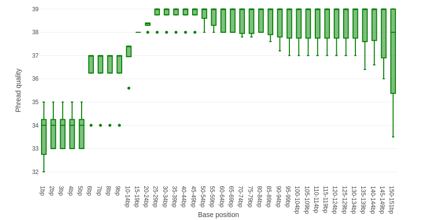

Forward strand

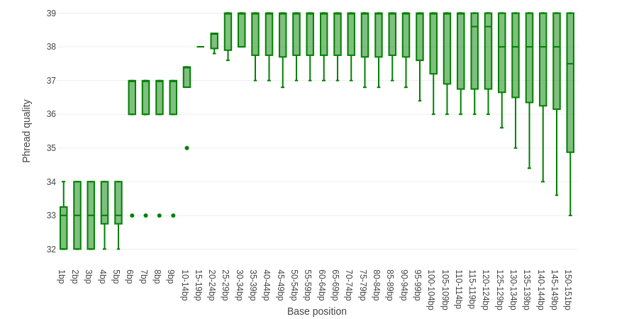

Reverse strand

### 2.2.3 Third trim

| Input Parameter | Value |
| --- | --- |
| Single-end or paired-end reads? | pair_of_files |
| Input FASTQ file (R1/first of pair) | *R1 file* |
| Input FASTQ file (R2/second of pair) | *R2 file* |
| Perform initial ILLUMINACLIP step? | true |
| Select standard adapter sequences or provide custom? | standard |
| Adapter sequences to use | TruSeq3 (paired-ended, for MiSeq and HiSeq) |
| Maximum mismatch count which will still allow a full match to be performed | 2 |
| How accurate the match between the two ‘adapter ligated’ reads must be for PE palindrome read alignment | 30 |
| How accurate the match between any adapter etc. sequence must be against a read | 10 |
| Minimum length of adapter that needs to be detected (PE specific/palindrome mode) | 8 |
| Always keep both reads (PE specific/palindrome mode)? | true |
| Select Trimmomatic operation to perform | SLIDINGWINDOW |
| Number of bases to average across | 4 |
| Average quality required | 30 |
| Select Trimmomatic operation to perform | MINLEN |
| Minimum length of reads to be kept | 100 |
| Quality score encoding | Nothing selected. |
| Output trimlog file? | false |
| Output trimmomatic log messages? | false |

#### 2.2.3.1 Basic Statistics

| Measure | Value |
| --- | --- |
| Filename |  |
| File type | Conventional base calls |
| Encoding | Sanger / Illumina 1.9 |
| Total Sequences | 639254 |
| Sequences Flagged As Poor Quality | 0 |
| Sequence length | 100 - 151 |
| %GC: | 41 |

#### 2.2.3.2 Per base sequence quality

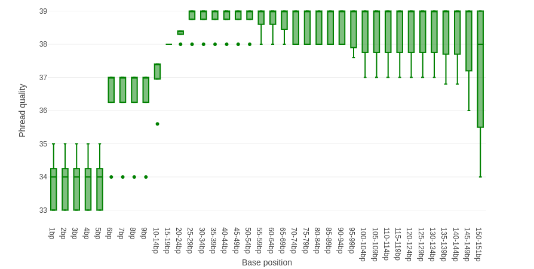

Forward strand

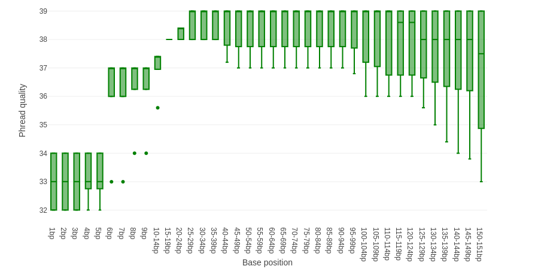

Reverse strand

### 2.2.4 Fourth trim

| Input Parameter | Value |
| --- | --- |
| Single-end or paired-end reads? | pair_of_files |
| Input FASTQ file (R1/first of pair) | *R1 file* |
| Input FASTQ file (R2/second of pair) | *R2 file* |
| Perform initial ILLUMINACLIP step? | true |
| Select standard adapter sequences or provide custom? | standard |
| Adapter sequences to use | TruSeq3 (paired-ended, for MiSeq and HiSeq) |
| Maximum mismatch count which will still allow a full match to be performed | 2 |
| How accurate the match between the two ‘adapter ligated’ reads must be for PE palindrome read alignment | 30 |
| How accurate the match between any adapter etc. sequence must be against a read | 10 |
| Minimum length of adapter that needs to be detected (PE specific/palindrome mode) | 8 |
| Always keep both reads (PE specific/palindrome mode)? | true |
| Select Trimmomatic operation to perform | SLIDINGWINDOW |
| Number of bases to average across | 4 |
| Average quality required | 30 |
| Select Trimmomatic operation to perform | MINLEN |
| Minimum length of reads to be kept | 50 |
| Quality score encoding | Nothing selected. |
| Output trimlog file? | false |
| Output trimmomatic log messages? | false |

#### 2.2.4.1 Basic Statistics

| Measure | Value |
| --- | --- |
| Filename |  |
| File type | Conventional base calls |
| Encoding | Sanger / Illumina 1.9 |
| Total Sequences | 822515 |
| Sequences Flagged As Poor Quality | 0 |
| Sequence length | 50 - 151 |
| %GC: | 42 |

#### 2.2.4.2 Per base sequence quality

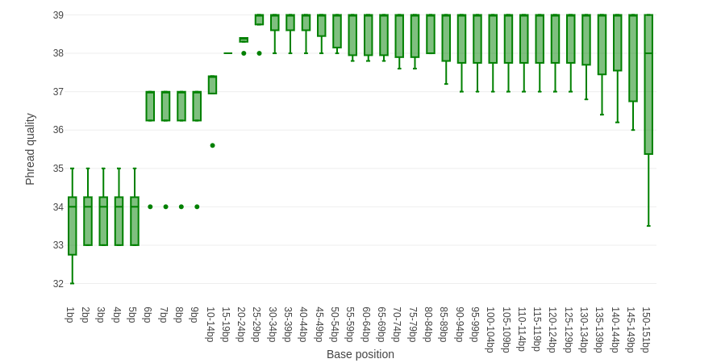

Forward strand

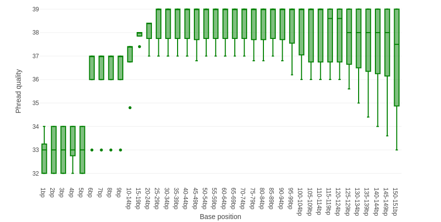

Reverse strand

### 2.2.5 Fifth trim

| Input Parameter | Value |
| --- | --- |
| Single-end or paired-end reads? | pair_of_files |
| Input FASTQ file (R1/first of pair) | *R1 file* |
| Input FASTQ file (R2/second of pair) | *R2 file* |
| Perform initial ILLUMINACLIP step? | true |
| Select standard adapter sequences or provide custom? | standard |
| Adapter sequences to use | TruSeq3 (paired-ended, for MiSeq and HiSeq) |
| Maximum mismatch count which will still allow a full match to be performed | 2 |
| How accurate the match between the two ‘adapter ligated’ reads must be for PE palindrome read alignment | 30 |
| How accurate the match between any adapter etc. sequence must be against a read | 10 |
| Minimum length of adapter that needs to be detected (PE specific/palindrome mode) | 8 |
| Always keep both reads (PE specific/palindrome mode)? | true |
| Select Trimmomatic operation to perform | SLIDINGWINDOW |
| Number of bases to average across | 4 |
| Average quality required | 20 |
| Select Trimmomatic operation to perform | MINLEN |
| Minimum length of reads to be kept | 50 |
| Quality score encoding | Nothing selected. |
| Output trimlog file? | false |
| Output trimmomatic log messages? | false |

#### 2.2.5.1 Basic Statistics

| Measure | Value |
| --- | --- |
| Filename |  |
| File type | Conventional base calls |
| Encoding | Sanger / Illumina 1.9 |
| Total Sequences | 1224621 |
| Sequences Flagged As Poor Quality | 0 |
| Sequence length | 50 - 151 |
| %GC: | 42 |

#### 2.2.5.2 Per base sequence quality

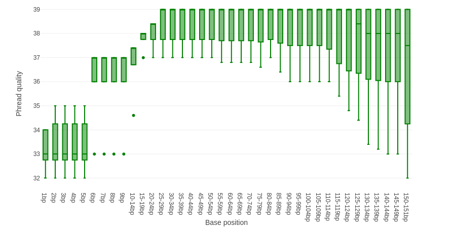

Forward strand

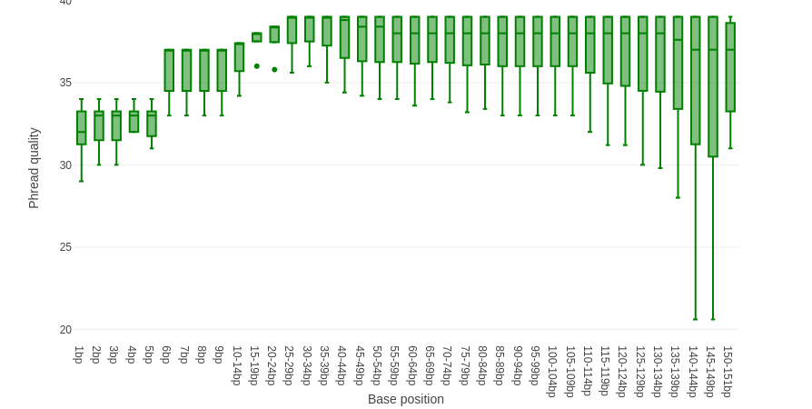

Reverse strand

### 2.2.6 Results

| Trim number | Avg. quality required | Min. read length to keep | % sequences removed |
| --- | --- | --- | --- |
| 1st | 20 | 70 | 17.7 |
| 2nd | 30 | 70 | 47.05 |
| 3rd | 30 | 100 | 55.12 |
| 4th | 30 | 50 | 42.25 |
| 5th | 20 | 50 | 14.02 |

## 2.3 Mapping

### 2.3.1 Expected coverage

A sequence’s coverage or read depth is the average amount of reads of each region in a given genome. To calculate the coverage we can use the formula `C = LN/G`, where `C = coverage`, `L = read length`, `N = number of reads` and `G = captured region`. This results in an expected or estimated coverage, as many reads could not be distributed evenly.

```r
Coverage <- function(readLength, readAmount, capturedRegion){
  (readLength * readAmount) / capturedRegion
}
```

```r
# Our expected coverage on CardioPanel
#
# 50 min. & 138 max. sequence length
# 1206159 total sequences, times 2 strands
# 320000 bases for the CarioPanel
Coverage(88, 1206159 * 2, 320000)
```

```
## [1] 663.3874
```

```r
# "Max Illumina sequencer coverage on CardioPanel
#
# 300 max Illumina sequence length
# 25000000 max Illumina reads
# 320000 bases for the CardioPanel
Coverage(300, 25000000, 320000)
```

```
## [1] 23437.5
```

The resulting expected read depth is ~ 663. Which means spotted DNA variants should be of high confidence. However, the actual coverage of each region should be also checked after the following mapping steps.

### 2.3.2 Mapping with BWA

| Input Parameter | Value |
| --- | --- |
| Will you select a reference genome from your history or use a built-in index? | cached |
| Using reference genome | hg38 |
| Single or Paired-end reads | paired |
| Select first set of reads |  |
| Select second set of reads |  |
| Enter mean, standard deviation, max, and min for insert lengths. | Not available. |
| Set read groups information? | do_not_set |
| Select analysis mode | illumina |
| BAM sorting mode | Sort by chromosomal coordinates |

```
Map with BWA-MEM - map medium and long reads (> 100 bp) against reference genome
(Galaxy Version 0.7.19)
```

### 2.3.3 Marking duplicate mapped reads

[output not shown]

### 2.3.5 Variant calling

The following variant is on the TTN gene. The nucleotide **A** from the reference gene is replaced with a **C**, which only changes one aminoacid (threonine is replaced with proline).

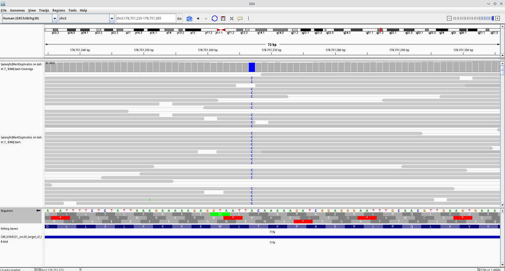

IGV tool variant visualization at position: chr2:178,751,235-178,751,305

## 2.4 Mapping Quality Control

### 2.4.1 BED-data

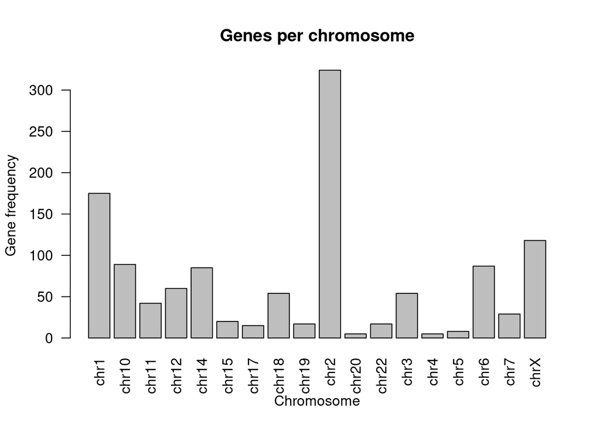

```r
refGen <- read.table("./Reference-hg38.bed")
names(refGen) <- c("Chromosome", "Exon Start", "Exon End", "Gene")

chrCount <- tapply(refGen$Gene, refGen$Chromosome, length)

barplot(chrCount, las = 2,
        xlab = "Chromosome", ylab = "Gene frequency",
        main = "Genes per chromosome")
```

### 2.4.2 Bioconductor

```r
# This package contains the 'IRanges', 'GRanges' and 'GRangesList' classes we will use
library(GenomicRanges)
```

```r
( SOD2 <- refGen[refGen$Gene == "SOD2",] )
```

```
##     Chromosome Exon Start  Exon End Gene
## 649       chr6  159682473 159682658 SOD2
## 650       chr6  159684834 159685053 SOD2
## 651       chr6  159688106 159688262 SOD2
## 652       chr6  159692641 159692883 SOD2
## 653       chr6  159693125 159693187 SOD2
```

```r
( iranges <- IRanges(start = SOD2$`Exon Start`, end = SOD2$`Exon End`, names = SOD2$Gene) )
```

```
## IRanges object with 5 ranges and 0 metadata columns:
##            start       end     width
##        <integer> <integer> <integer>
##   SOD2 159682473 159682658       186
##   SOD2 159684834 159685053       220
##   SOD2 159688106 159688262       157
##   SOD2 159692641 159692883       243
##   SOD2 159693125 159693187        63
```

```r
cat("Length of SOD2:", sum( width(iranges) ), "bp")
```

```
## Length of SOD2: 869 bp
```

```r
( granges <- GRanges(seqnames = SOD2$Chromosome, ranges = iranges) )
```

```
## GRanges object with 5 ranges and 0 metadata columns:
##        seqnames              ranges strand
##           <Rle>           <IRanges>  <Rle>
##   SOD2     chr6 159682473-159682658      *
##   SOD2     chr6 159684834-159685053      *
##   SOD2     chr6 159688106-159688262      *
##   SOD2     chr6 159692641-159692883      *
##   SOD2     chr6 159693125-159693187      *
##   -------
##   seqinfo: 1 sequence from an unspecified genome; no seqlengths
```

```r
geneList <- list()
unique(refGen$Gene)
```

```
##  [1] "NEXN"   "LMNA"   "TNNT2"  "PSEN2"  "ACTN2"  "RYR2"   "TTN"    "DES"
##  [9] "CAV3"   "TMEM43" "SCN5A"  "MYL3"   "TNNC1"  "MYOZ2"  "SGCD"   "DSP"
## [17] "LAMA4"  "PLN"    "EYA4"   "SOD2"   "TBX20"  "GATAD1" "PRKAG2" "MYPN"
## [25] "MYOZ1"  "VCL"    "LDB3"   "ANKRD1" "RBM20"  "BAG3"   "CSRP3"  "MYBPC3"
## [33] "CRYAB"  "ABCC9"  "PKP2"   "MYL2"   "MYH6"   "MYH7"   "PSEN1"  "ACTC1"
## [41] "TPM1"   "TCAP"   "JUP"    "DSC2"   "DSG2"   "DTNA"   "CALR3"  "TNNI3"
## [49] "JPH2"   "TXNRD2" "DMD"    "GLA"    "LAMP2"  "EMD"    "TAZ"
```

```r
for (geneName in unique(refGen$Gene)){
  gene <- refGen[refGen$Gene == geneName,]
  iranges <- IRanges(start = gene$`Exon Start`, end = gene$`Exon End`, names = gene$Gene)
  granges <- GRanges(seqnames = gene$Chromosome, ranges = iranges)
  geneList[[geneName]] <- granges
}

geneList <- GRangesList(geneList)
geneList
```

```
## GRangesList object of length 55:
## $NEXN
## GRanges object with 12 ranges and 0 metadata columns:
##        seqnames            ranges strand
##           <Rle>         <IRanges>  <Rle>
##   NEXN     chr1 77916084-77916153      *
##   NEXN     chr1 77917546-77917777      *
##   NEXN     chr1 77917940-77918058      *
##   NEXN     chr1 77918105-77918293      *
##   NEXN     chr1 77925168-77925249      *
##    ...      ...               ...    ...
##   NEXN     chr1 77929296-77929524      *
##   NEXN     chr1 77933262-77933499      *
##   NEXN     chr1 77935803-77936064      *
##   NEXN     chr1 77942003-77942228      *
##   NEXN     chr1 77942441-77942849      *
##   -------
##   seqinfo: 18 sequences from an unspecified genome; no seqlengths
##
## ...
## <54 more elements>
```

### 2.4.3 Gene Lengths

```r
library(plotrix)
```

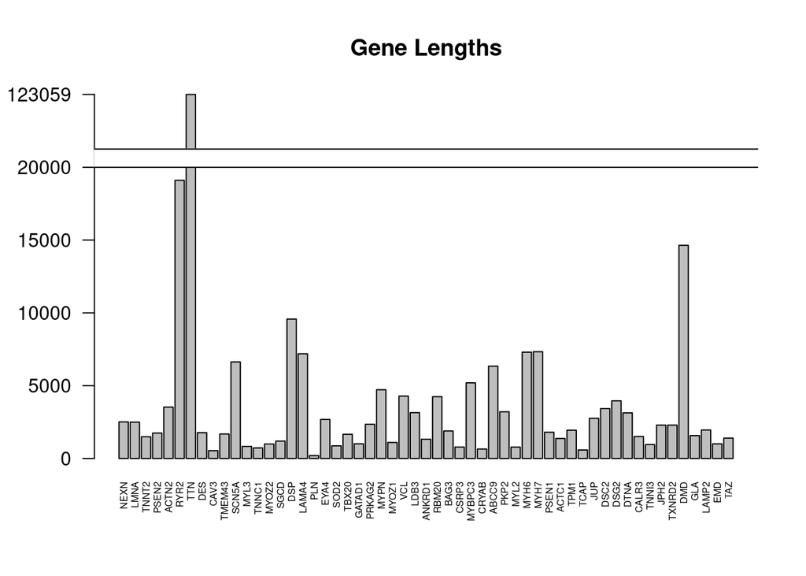

```r
geneLengths <- sum(width(ranges(geneList)))
# Originally 123059
geneLengths["TTN"] <- 25000

barplot(geneLengths, axes = F, cex.names = 0.5, las = 2, ylim = c(0, 25000), main = "Gene Lengths")
axis(2, at = c(0, 5000, 10000, 15000, 20000, 25000),
     labels = c("0", "5000", "10000", "15000", "20000", "123059"), las = 2)
axis.break(2, 20000, style = "gap", brw = 0.05)
```

### 2.4.4 Loading the Mapped Reads

```r
# Loading the RSamtools library
library(Rsamtools)
```

```r
bamFile <- BamFile("./MapReads.bam", index = "./MapReads.bai")
bamParam <- ScanBamParam(which = geneList[["NEXN"]], what = scanBamWhat())

bamPileup <- pileup(file = bamFile, scanBamParam = bamParam)
head(bamPileup)
```

```
##   seqnames      pos strand nucleotide count            which_label
## 1     chr1 77916084      +          G   196 chr1:77916084-77916153
## 2     chr1 77916084      -          G    65 chr1:77916084-77916153
## 3     chr1 77916085      +          C   195 chr1:77916084-77916153
## 4     chr1 77916085      -          C    65 chr1:77916084-77916153
## 5     chr1 77916086      +          C   195 chr1:77916084-77916153
## 6     chr1 77916086      -          C    66 chr1:77916084-77916153
```

### 2.4.5 Pileup Processing

```r
genePileupList <- list()


for (geneName in names(geneList)) {
  bamParam <- ScanBamParam(which = geneList[[geneName]], what = scanBamWhat())
  bamPileup <- pileup(file = bamFile, scanBamParam = bamParam)
  genePileupList[[geneName]] <- bamPileup
}

head(genePileupList[["NEXN"]])
```

```
##   seqnames      pos strand nucleotide count            which_label
## 1     chr1 77916084      +          G   196 chr1:77916084-77916153
## 2     chr1 77916084      -          G    65 chr1:77916084-77916153
## 3     chr1 77916085      +          C   195 chr1:77916084-77916153
## 4     chr1 77916085      -          C    65 chr1:77916084-77916153
## 5     chr1 77916086      +          C   195 chr1:77916084-77916153
## 6     chr1 77916086      -          C    66 chr1:77916084-77916153
```

### 2.4.6 Coverage calculation and reporting

```r
coverage = aggregate(x = list(count = genePileupList[["NEXN"]]$count),
                     by = list(pos = genePileupList[["NEXN"]]$pos), FUN=sum)
head(coverage)
```

```
##        pos count
## 1 77916084   261
## 2 77916085   260
## 3 77916086   261
## 4 77916087   261
## 5 77916088   259
## 6 77916089   258
```

```r
geneCoverageList <- list()

for (geneName in names(geneList)) {
  coverage = aggregate(x = list(count = genePileupList[[geneName]]$count),
                     by = list(pos = genePileupList[[geneName]]$pos), FUN=sum)
  geneCoverageList[[geneName]] <- coverage
}
```

```r
positionCount <- c()
averageCoverage <- c()
lowCoverageConstant <- 20
lowCoverage <- c()

for (geneName in names(geneList)) {
  positionCount <- c(positionCount,
                     length(geneCoverageList[[geneName]]$pos))
  averageCoverage <- c(averageCoverage,
                       round(mean(geneCoverageList[[geneName]]$count), digits = 1))
  lowCoverage <- c(lowCoverage,
                   length(geneCoverageList[[geneName]]$count[geneCoverageList[[geneName]]$count < lowCoverageConstant]))
}

lowCoveragePercent <- round((lowCoverage / positionCount) * 100, digits = 1)

geneCoveragePositions <-
  data.frame(
    row.names = names(geneCoverageList),
    length = positionCount,
    avg_coverage = averageCoverage,
    low_coverage = lowCoverage,
    low_coverage_perc = lowCoveragePercent
  )
geneCoveragePositions
```

```
##        length avg_coverage low_coverage low_coverage_perc
## NEXN     2511        246.1            0               0.0
## LMNA     2496         79.4           36               1.4
## TNNT2    1458        197.1            0               0.0
## PSEN2    1747        146.9           14               0.8
## ACTN2    3527        182.9            0               0.0
## RYR2    19104        244.7            1               0.0
## TTN    123059        248.9            0               0.0
## DES      1774        118.9          126               7.1
## CAV3      536        192.0            0               0.0
## TMEM43   1683        175.1           22               1.3
## SCN5A    6633        158.8           13               0.2
## MYL3      828        161.1            0               0.0
## TNNC1     726        171.6            0               0.0
## MYOZ2     995        250.4            0               0.0
## SGCD     1193        231.4            0               0.0
## DSP      9577        235.5            0               0.0
## LAMA4    7193        233.5            0               0.0
## PLN       199        229.2            0               0.0
## EYA4     2683        250.0            0               0.0
## SOD2      869        182.6            0               0.0
## TBX20    1664        191.2           48               2.9
## GATAD1   1010        182.1          149              14.8
## PRKAG2   2350        181.4          252              10.7
## MYPN     4723        242.2            0               0.0
## MYOZ1    1100        226.2            0               0.0
## VCL      4285        208.2           61               1.4
## LDB3     3148        141.2           32               1.0
## ANKRD1   1322        229.8            0               0.0
## RBM20    4243        212.5          173               4.1
## BAG3     1892        205.1            0               0.0
## CSRP3     785        228.7            0               0.0
## MYBPC3   5195        119.3          417               8.0
## CRYAB     650        151.9            0               0.0
## ABCC9    6339        247.8            0               0.0
## PKP2     3206        205.1          263               8.2
## MYL2      781        207.2            0               0.0
## MYH6     7301        196.0           29               0.4
## MYH7     7329        201.4            0               0.0
## PSEN1    1804        240.2            0               0.0
## ACTC1    1375        189.4           22               1.6
## TPM1     1941        181.7          326              16.8
## TCAP      584         77.4            0               0.0
## JUP      2758         75.6           42               1.5
## DSC2     3427        236.5            0               0.0
## DSG2     3959        238.0           86               2.2
## DTNA     3133        235.6            0               0.0
## CALR3    1511        241.4            0               0.0
## TNNI3     953        103.1            0               0.0
## JPH2     2292         87.7          548              23.9
## TXNRD2   2293        127.6          143               6.2
## DMD     14643        246.6            0               0.0
## GLA      1570        236.5            0               0.0
## LAMP2    1957        236.9            0               0.0
## EMD      1006        168.3            0               0.0
## TAZ      1400        163.4            0               0.0
```

## 2.5 Analysis of Variants

| Input Parameter | Value |
| --- | --- |
| Input reads in BAM format |  |
| Choose the source for the reference genome | cached |
| Reference genome | hg38 |
| Call variants across | genome |
| Types of variants to call | Only SNVs |
| Variant calling parameters | false |
| Variant filter parameters | set_lofreq_standard |
| sig | 0.01 |
| bonf | dynamic |
| others | Empty. |

```
Call variants with LoFreq
(Galaxy Version 2.1.5+galaxy3)
```

### 2.5.1 VCF File Processing

```r
vcfFile <- read.delim("./CallVariants.vcf", stringsAsFactors = FALSE, comment = "#")
head(vcfFile)
```

```
##   CHROM      POS ID REF ALT QUAL FILTER                                 INFO
## 1  chr1 27325641  .   A   G  144   PASS     DP=16;AF=0.3125;SB=0;DP4=9,2,5,0
## 2  chr1 71625045  .   C   T  147   PASS   DP=14;AF=0.428571;SB=0;DP4=8,0,6,0
## 3  chr1 71625166  .   C   A  517   PASS DP=31;AF=0.548387;SB=0;DP4=14,0,17,0
## 4  chr1 71625235  .   G   T  729   PASS DP=46;AF=0.543478;SB=1;DP4=14,7,18,7
## 5  chr1 77774432  .   T   C  425   PASS       DP=20;AF=0.65;SB=0;DP4=4,3,6,7
## 6  chr1 77917782  .   G   A 5119   PASS   DP=332;AF=0.5;SB=4;DP4=95,71,85,81
```

```r
vcfInfo <- do.call(rbind,
  strsplit(vcfFile$INFO, ";"))

vcfInfo <- data.frame(vcfInfo)
names(vcfInfo) <- c("DP", "AF", "SB", "DP4")

vcfInfo$AF <- as.numeric(gsub("AF=", x = vcfInfo$AF, ""))
```

```r
vcfIRanges <- IRanges(start = vcfFile$POS, end = vcfFile$POS)

vcfGRanges <- GRanges(seqnames = vcfFile$CHROM, ranges = vcfIRanges)

mcols(vcfGRanges) <- DataFrame(AF = vcfInfo$AF)

( vcfGRanges <- vcfGRanges[vcfGRanges$AF >= 0.3] )
```

```
## GRanges object with 1108 ranges and 1 metadata column:
##          seqnames    ranges strand |        AF
##             <Rle> <IRanges>  <Rle> | <numeric>
##      [1]     chr1  27325641      * |  0.312500
##      [2]     chr1  71625045      * |  0.428571
##      [3]     chr1  71625166      * |  0.548387
##      [4]     chr1  71625235      * |  0.543478
##      [5]     chr1  77774432      * |  0.650000
##      ...      ...       ...    ... .       ...
##   [1104]     chrX  76653828      * |  0.538462
##   [1105]     chrX 114758092      * |  1.000000
##   [1106]     chrX 144264053      * |  0.733333
##   [1107]     chrX 154412069      * |  1.000000
##   [1108]     chrX 154421359      * |  0.457143
##   -------
##   seqinfo: 26 sequences from an unspecified genome; no seqlengths
```

```r
overlaps <- findOverlaps(vcfGRanges, geneList)
overlaps <- DataFrame(overlaps)
overlaps
```

```
## DataFrame with 129 rows and 2 columns
##     queryHits subjectHits
##     <integer>   <integer>
## 1          21           2
## 2          23           2
## 3          24           2
## 4          35           3
## 5          36           3
## ...       ...         ...
## 125      1085          51
## 126      1090          51
## 127      1097          51
## 128      1098          51
## 129      1107          55
```

```r
vcfLines <- readLines("./CallVariants.vcf")
vcfHeader <- vcfLines[1:146]
vcfData <- vcfLines[overlaps$queryHits + 147]
writeLines(c(vcfHeader, vcfData), "./CallVariantsFiltered.vcf")
```

### 2.5.2 Variant Visualization

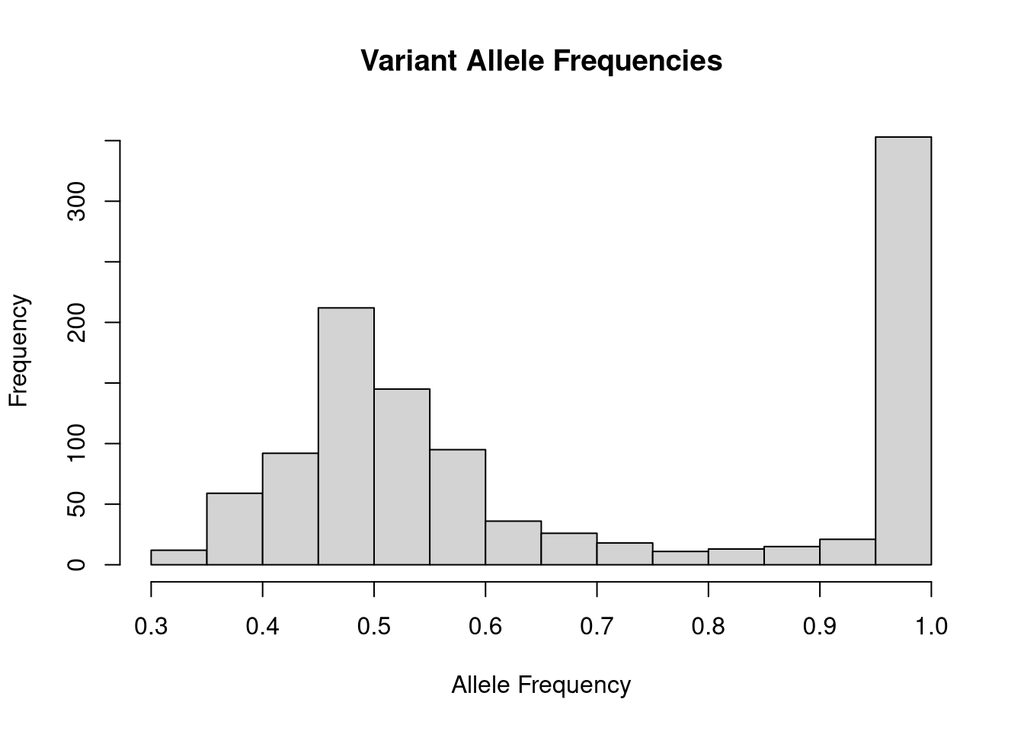

```r
hist(vcfGRanges$AF, xlab = "Allele Frequency", main = "Variant Allele Frequencies")
```

The 50% peak represents heterozygous genes and the 100% peak represents homozygous genes. Heterozygous genes are two different versions of the same gene and homozygous are two genes of same version, both acquired from the parents.

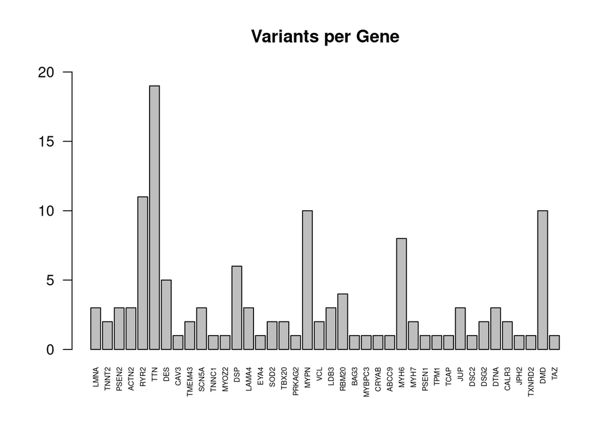

```r
variantFreq <- table(overlaps$subjectHits)
names(variantFreq) <- names(geneList)[as.integer(names(variantFreq))]

barplot(variantFreq, las = 2, cex.names = 0.5, ylim = c(0, 20), main = "Variants per Gene")
```

## 2.6 Variant Annotation

### 2.6.1 SnpEff and SnpSift

Ran the tool `SnpEff` to annotate the filtered `vcf` file from the previous step. This adds metadata fields about each variant and predictions on their effects.

```
SnpEff eff  annotate variants
(Galaxy Version 5.4+galaxy0)
```

Ran the tool `SnpSift` to further annotate our `vcf` file. This tool compares the resulting `vcf` file from the `SnpEff` step together with a `dbSnp` database file. The result expands on the metadata added by `SnpEff` and adds an ID field, which serves as an identifier for the variant in the NCBI database.

```
SnpSift Annotate SNPs from dbSnp
(Galaxy Version 5.4.0c+galaxy0)
```

One last pass with `SnipSift`, this time through a command to add metadata from the NSFP database.

```bash
java -jar /data/datasets/dbNSFP/snpEff/SnpSift.jar DbNsfp -db /data/datasets/dbNSFP/snpEff/data/dbNSFP5.3.1a_grch38.gz -n SnpVariants_Step2.vcf > SnpVariants_Step3.vcf
```

In this section we can parse our `vcf` file in order to generate a table with descriptions about all the fields added.

```r
library(stringr)
```

```r
#Read metadata description fields from final vcf file
snpVcf <- readLines("./SnpVariants_Step3.vcf")
snpVcf <- snpVcf[str_detect(snpVcf, "##INFO")]

#Remove identifier fields
snpVcf <- str_remove_all(snpVcf, "(##INFO=<ID=|Number=|Type=|Description=|\\\\|\"|>)")
snpVcf <- str_replace_all(snpVcf, ",\\s", "; ")

#Create table from resulting values
snpVcf <- read.table(text = snpVcf, sep = ",", fill = T, stringsAsFactors = FALSE, quote = "", col.names = c("ID", "Number", "Type", "Description"))

#Assign database
#Index 1 to 7 are from database Human Genome 38 (hg.38)
#Index 8 to 10 are from database GRCh38.p14, assignment step 1 (SnpEff)
#Index 11 to 31 are from database dbSnp_clinvar, assignment step 2 (SnpSift)
#Index 32 to 536 are from database dbNSFP, assignment step 3 (SnpSift)
snpVcf$Database <- c(replicate(7, "hg.38"), replicate(3, "GRCh38.p14"), replicate(21, "dbSnp_clinvar"), replicate(505, "dbNSFP5.3.1a"))
```

### 2.6.2 Analyzing Variant Annotation

```r
#Read text documentation file
nsfpDocs <- readLines("./dbNSFP5.3.1a.readme.txt")
#Vector of IDs to compare against the many entries in the file
nsfpIDs <- snpVcf$ID[32:536]
nsfpIDs <- str_remove_all(nsfpIDs, " ")
nsfpIDs <- paste0(nsfpIDs, ":")

#Look up and add descriptions in correct order
#IMPORTANT: File has been edited with an IDE in order to simplify this R code.
nsfpDocsLines <- c()
for (id in nsfpIDs) {
  newLine <- nsfpDocs[str_detect(nsfpDocs, id)]
  if (length(newLine) > 1) {
    nsfpDocsLines <- c(nsfpDocsLines, newLine[1])
    next
  }
  if (identical(newLine, character(0))) {
    nsfpDocsLines <- c(nsfpDocsLines, "")
    next
  }
  nsfpDocsLines <- c(nsfpDocsLines, newLine)
}

#Remove unnecessary strings
nsfpDocsLines <- str_remove_all(nsfpDocsLines, "(.+:\\s|\\\t|\\\\|\")")

#Assign new descriptions to corresponding entries
snpVcf$Description[32:536] <- nsfpDocsLines
```

```bash
java -jar /data/datasets/dbNSFP/snpEff/SnpSift.jar extractFields SnpVariants_Step3.vcf -s ";" CHROM POS ID REF ALT FILTER ANN[*].EFFECT ANN[*].IMPACT ANN[*].GENE ANN[*].FEATURE ANN[*].FEATUREID ANN[*].BIOTYPE CLNDN CLNSIG CLNVC dbNSFP_gnomAD4.1_joint_POPMAX_AF dbNSFP_gnomAD2.1.1_exomes_controls_POPMAX_AF dbNSFP_REVEL_score dbNSFP_SIFT_pred dbNSFP_SIFT_score dbNSFP_Polyphen2_HDIV_pred dbNSFP_Polyphen2_HVAR_pred dbNSFP_MutationTaster_pred dbNSFP_CADD_phred dbNSFP_VEST4_score dbNSFP_ESM1b_pred dbNSFP_phyloP100way_vertebrate dbNSFP_GERP___NR dbNSFP_GERP___RS dbNSFP_fathmm_XF_coding_pred dbNSFP_BayesDel_addAF_pred dbNSFP_MetaSVM_pred dbNSFP_MetaLR_pred > SnpVariants_Filtered.txt
```

```r
library(tidyverse)
```

```r
snpFilteredVariants <- read.table("./FilteredTEST.tabular", sep = "", quote = "", fill = T, header = T)

snpFilteredVariants <- filter(snpFilteredVariants, str_detect(snpFilteredVariants$ANN....EFFECT, "(missense_variant|splice_region_variant)"))
snpFilteredVariants
```

```
##     CHROM       POS     ID REF ALT FILTER                        ANN....EFFECT
## 1   chr10  86668578 138106   T   C   PASS splice_region_variant&intron_variant
## 2   chr10  86668578 138106   T   C   PASS splice_region_variant&intron_variant
## 3   chr10  86668578 138106   T   C   PASS splice_region_variant&intron_variant
## 4   chr10  86668578 138106   T   C   PASS splice_region_variant&intron_variant
## 5   chr10  86668578 138106   T   C   PASS splice_region_variant&intron_variant
## 6   chr10  86668578 138106   T   C   PASS splice_region_variant&intron_variant
## 7   chr10  86668578 138106   T   C   PASS splice_region_variant&intron_variant
## 8   chr10  86668578 138106   T   C   PASS splice_region_variant&intron_variant
## 9   chr14  23392602  44480   A   G   PASS                     missense_variant
## 10   chr2 130463597      .   C   T   PASS                     missense_variant
## 11   chr2 130463597      .   C   T   PASS                     missense_variant
## 12   chr2 130463597      .   C   T   PASS                     missense_variant
## 13   chr2 130463597      .   C   T   PASS                     missense_variant
## 14   chr2 130463597      .   C   T   PASS                     missense_variant
```

[output cut: 2241 more lines]

```r
#snpFilteredVariantsCollapsed <- distinct(snpFilteredVariants, snpFilteredVariants$POS, .keep_all = T)

#for (pos in snpFilteredVariantsCollapsed$POS) {
 # p <- filter(snpFilteredVariants, str_detect(snpFilteredVariants$POS, as.character(pos)))
  #snpFilteredVariantsCollapsed$ANN....FEATUREID[which(snpFilteredVariantsCollapsed$POS == pos)] <- paste(p$ANN....FEATUREID, collapse = "|")
#}
#snpFilteredVariantsCollapsed
```

| Position | Variant |
| --- | --- |
| 86668578 | [NM_001171610.2](https://www.ncbi.nlm.nih.gov/clinvar/variation/4812043/) |
| 23392602 | [NM_002471.4](https://www.ncbi.nlm.nih.gov/clinvar/variation/4813436/) |
| 130463597 | [NM_001371926.1](https://www.ncbi.nlm.nih.gov/clinvar/variation/3770524/) |
| 131264056 | [NM_001083538.3](https://www.ncbi.nlm.nih.gov/clinvar/variation/2651372/) |
| 178580041 | [NM_001267550.2](https://www.ncbi.nlm.nih.gov/clinvar/variation/514880/) |
| 178597531 | [NM_001267550.2](https://www.ncbi.nlm.nih.gov/clinvar/variation/514880/) |
| 178715250 | [NM_001267550.2](https://www.ncbi.nlm.nih.gov/clinvar/variation/514880/) |
| 178777698 | [NM_001267550.2](https://www.ncbi.nlm.nih.gov/clinvar/variation/514880/) |
| 31478309 | [NM_004006.3](https://www.ncbi.nlm.nih.gov/clinvar/variation/264223/) |
| 31478314 | [NM_004006.3](https://www.ncbi.nlm.nih.gov/clinvar/variation/264223/) |

## 2.7 Variant Visualization

```r
library(trackViewer)
```

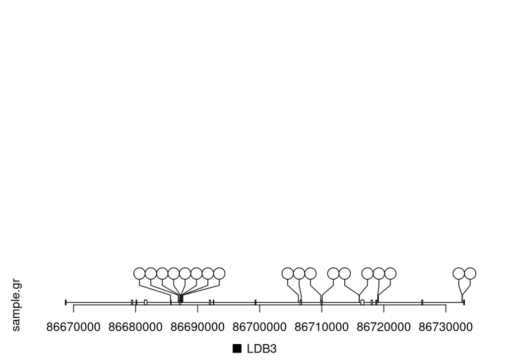

```r
sample.gr <- vcfGRanges
features <- geneList$LDB3
lolliplot(sample.gr, features)
```